# Practical Machine Learning Course Project

mdoucem

31 January 2018

## Overview

One thing that people regularly do is quantify how much of a particular activity they do, but they rarely quantify how well they do it. In the following, we will use data from accelerometers on the belt, forearm, arm, and dumbell of 6 participants to predict the manner in which the exercises were done.

## Let’s load first the necessary libraries

```r
library(ggplot2)
library(caret)
library(knitr)
library(rmarkdown)
library(corrplot)
library(mlbench)
```

## Download the data

We use data collected from devices such as Jawbone Up, Nike FuelBand, and Fitbit. The data has been divided into a training set and a test set.

We first dowload the data

```r
train_url<-"https://d396qusza40orc.cloudfront.net/predmachlearn/pml-training.csv"
test_url<-"https://d396qusza40orc.cloudfront.net/predmachlearn/pml-testing.csv"

train_des<-"train_set.csv"
test_des<-"test_set.csv"

if (!file.exists(train_des) & !file.exists(test_des)){
  trainfile<-download.file(train_url, train_des, method = "libcurl")
  testfile<-download.file(test_url, test_des, method = "libcurl")
}
```

After downloading the data, we then read in the data for exploration and analysis.

## Read in the data

```r
trainset<-read.csv("train_set.csv", sep = ",", stringsAsFactors = FALSE, na.strings = c("NA","#DIV/0!",""))
testset<-read.csv("test_set.csv", sep = ",", stringsAsFactors = FALSE, na.strings = c("NA","#DIV/0!",""))
```

Let us look at how this data looks like:

```r
dim(trainset)
```

```
## [1] 19622   160
```

The training set has 19,622 observations and 160 variables, while

```r
dim(testset)
```

```
## [1]  20 160
```

The test set has 20 observations and 160 variables

## Cleaning the data

When looking at the data, e.g., use str(trainset). We see that the datasets have a lot of observations that are zero or missing. Thus we have to deal with them in some way.

Let us first see how many missing values are in the training set

```r
sum(is.na(trainset)) # there are a total of 1925102 missing values
```

```
## [1] 1925102
```

We deal with these values in two ways: First using nearZeroVar function to deal with those variables that near zero variance. Secondly, remiving the NA values.

```r
zero_values<-nearZeroVar(trainset, saveMetrics = TRUE)
trainset<-trainset[, -unlist(zero_values)]
testset<-testset[, -unlist(zero_values)]
```

Let us look at the result of that

```r
dim(trainset)  #19,622 * 127
```

```
## [1] 19622   127
```

```r
dim(testset) #20 * 127
```

```
## [1]  20 127
```

Looking at the dimensions, we see that the number of variables is now 127 for both the train and test sets.

```r
missing_values<-sapply(trainset, function(x) mean(is.na(x))) >0.95
trainset<-trainset[, missing_values == FALSE]
testset<-testset[, missing_values == FALSE]
```

The result of removing missing values is that the

```r
dim(trainset) #19,622 * 44
```

```
## [1] 19622    44
```

```r
dim(testset) #20 * 44
```

```
## [1] 20 44
```

The number of variable for both the train and test are now 44.

## Analysis of the Training set

First, we look at the correlation between the variables

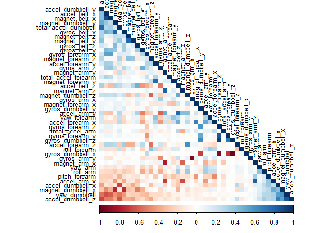

```r
corMatrix <- cor(trainset[,-44]) # remove the predictor column
corrplot(corMatrix, order = "FPC", method = "color", type = "lower",
         tl.cex = 0.8, tl.col = rgb(0,0,0)) # plot a correlation matrix
```

```r
inTrain<-createDataPartition(trainset$classe, p =0.8, list = FALSE)

training<-trainset[inTrain,]
validation<-trainset[-inTrain,]
```

## Predictive Modelling

The goal of the task is to build a good predictive model for the ‘classe’ variable.

For this task, I test 5 different algorithms, that are commonly used in machine learning tasks, and select the best performing one. In addition, I train the algorithms using 10-fold cross validation. Since the data set is large enough, 10-fold cross validation is good and reduces the chances of overfitting.

```r
control<-trainControl(method = "cv", number=10)
metric<-"Accuracy"
```

### Build the models

```r
# 1. LDA
set.seed(7) # should test different seeds as well
fit.lda<-train(as.factor(classe)~., data = training, method="lda", metric=metric, trControl=control)

# 2. CART
set.seed(7)
fit.cart<-train(as.factor(classe)~., data = training, method="rpart", metric=metric, trControl=control)

# 3. kNN
set.seed(7)
fit.knn<-train(as.factor(classe)~., data = training, method="knn", metric=metric, trControl=control)

# 4. SVM
set.seed(7)
fit.svm<-train(as.factor(classe)~., data = training, method="svmRadial", metric=metric, trControl=control)

# 5. Random Forest
set.seed(7)
fit.rf<-train(as.factor(classe)~., data = training, method="rf", metric=metric, trControl=control)
```

### Select the best model

```r
results<-resamples(list(lda=fit.lda, cart=fit.cart, knn=fit.knn,
                        svm=fit.svm, rf=fit.rf))
summary(results) # This plots the accuracy and kappa values of all the models
```

```
##
## Call:
## summary.resamples(object = results)
##
## Models: lda, cart, knn, svm, rf
## Number of resamples: 10
##
## Accuracy
##           Min.   1st Qu.    Median      Mean   3rd Qu.      Max. NA's
## lda  0.6416295 0.6479949 0.6533913 0.6554590 0.6637986 0.6687898    0
## cart 0.4748568 0.4906797 0.4977707 0.4990763 0.5108280 0.5200765    0
## knn  0.8872611 0.8986777 0.9015925 0.9017773 0.9063098 0.9121019    0
## svm  0.9096117 0.9200763 0.9219496 0.9234358 0.9254658 0.9375398    0
## rf   0.9872530 0.9888496 0.9901276 0.9901267 0.9914052 0.9936265    0
##
## Kappa
##           Min.   1st Qu.    Median      Mean   3rd Qu.      Max. NA's
## lda  0.5477038 0.5554456 0.5621087 0.5647388 0.5747214 0.5821768    0
## cart 0.3141647 0.3334517 0.3446139 0.3458315 0.3609479 0.3747591    0
## knn  0.8574937 0.8717581 0.8755418 0.8757068 0.8813982 0.8888067    0
## svm  0.8853899 0.8987693 0.9011003 0.9029907 0.9055716 0.9208770    0
## rf   0.9838751 0.9858914 0.9875102 0.9875084 0.9891276 0.9919372    0
```

From the results, we see the performance of all the five algorightms. From these results, we particularly see that the random forest algorithm has the best performance, with SVM coming in second.

These results can also be seen visually in the below figure.

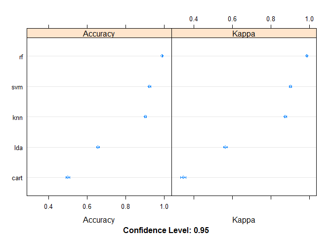

```r
dotplot(results)
```

I use the best two performing algorithms and test them on the validation set

```r
predictionsRf<-predict(fit.rf, validation)
predictionsSvm<-predict(fit.svm, validation)
```

With the following results:

```r
cmtrx1<-confusionMatrix(predictionsRf, validation$classe)
cmtrx1
```

```
## Confusion Matrix and Statistics
##
##           Reference
## Prediction    A    B    C    D    E
##          A 1114    5    0    0    0
##          B    1  752   10    0    0
##          C    0    2  674   17    0
##          D    1    0    0  625    2
##          E    0    0    0    1  719
##
## Overall Statistics
##
##                Accuracy : 0.9901
##                  95% CI : (0.9864, 0.9929)
##     No Information Rate : 0.2845
##     P-Value [Acc > NIR] : < 2.2e-16
##
##                   Kappa : 0.9874
##  Mcnemar's Test P-Value : NA
##
## Statistics by Class:
##
##                      Class: A Class: B Class: C Class: D Class: E
## Sensitivity            0.9982   0.9908   0.9854   0.9720   0.9972
## Specificity            0.9982   0.9965   0.9941   0.9991   0.9997
## Pos Pred Value         0.9955   0.9856   0.9726   0.9952   0.9986
## Neg Pred Value         0.9993   0.9978   0.9969   0.9945   0.9994
## Prevalence             0.2845   0.1935   0.1744   0.1639   0.1838
## Detection Rate         0.2840   0.1917   0.1718   0.1593   0.1833
## Detection Prevalence   0.2852   0.1945   0.1767   0.1601   0.1835
## Balanced Accuracy      0.9982   0.9937   0.9898   0.9855   0.9985
```

```r
cmtrx2<-confusionMatrix(predictionsSvm, validation$classe)
cmtrx2
```

```
## Confusion Matrix and Statistics
##
##           Reference
## Prediction    A    B    C    D    E
##          A 1099   64    6    5    3
##          B    4  669   33    3    2
##          C    4   26  635   73   28
##          D    8    0   10  562   21
##          E    1    0    0    0  667
##
## Overall Statistics
##
##                Accuracy : 0.9258
##                  95% CI : (0.9172, 0.9338)
##     No Information Rate : 0.2845
##     P-Value [Acc > NIR] : < 2.2e-16
##
##                   Kappa : 0.906
##  Mcnemar's Test P-Value : < 2.2e-16
##
## Statistics by Class:
##
##                      Class: A Class: B Class: C Class: D Class: E
## Sensitivity            0.9848   0.8814   0.9284   0.8740   0.9251
## Specificity            0.9722   0.9867   0.9596   0.9881   0.9997
## Pos Pred Value         0.9337   0.9409   0.8290   0.9351   0.9985
## Neg Pred Value         0.9938   0.9720   0.9845   0.9756   0.9834
## Prevalence             0.2845   0.1935   0.1744   0.1639   0.1838
## Detection Rate         0.2801   0.1705   0.1619   0.1433   0.1700
## Detection Prevalence   0.3000   0.1812   0.1953   0.1532   0.1703
## Balanced Accuracy      0.9785   0.9341   0.9440   0.9311   0.9624
```

From the above confusion matrix, we see that the Random Forest algorithm still has the best performance and is the one that is selected for predicting the ‘classe’ values for the test set.

In particular, it is good to see which variables have the most predictive power. Using the mlbench package, I find this out.

```r
importance<-varImp(fit.rf, scale = FALSE)
print(importance)
```

```
## rf variable importance
##
##   only 20 most important variables shown (out of 43)
##
##                      Overall
## magnet_dumbbell_z      523.0
## magnet_dumbbell_y      498.3
## pitch_forearm          470.7
## magnet_dumbbell_x      461.8
## accel_belt_z           450.2
## roll_forearm           429.2
## magnet_belt_z          418.5
## accel_dumbbell_y       412.7
## magnet_belt_y          394.9
## roll_arm               353.6
## accel_dumbbell_z       346.7
## accel_forearm_x        323.2
## accel_dumbbell_x       317.7
## gyros_belt_z           313.1
## yaw_dumbbell           302.6
## gyros_dumbbell_y       295.8
## total_accel_dumbbell   294.4
## magnet_arm_y           293.7
## magnet_forearm_z       288.8
## magnet_arm_x           283.5
```

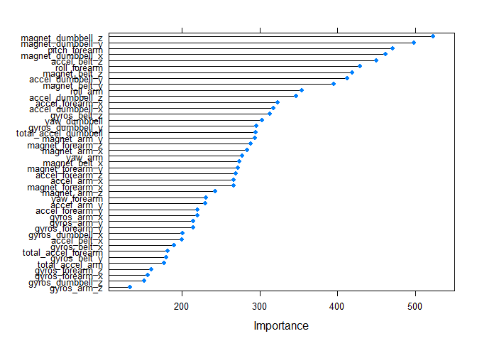

```r
plot(importance)
```

## Predicting the test set

Using the fit.rf model, we get the following:

```r
testpredictions<-predict(fit.rf, testset)
testpredictions
```

```
##  [1] B A B A A E D B A A B C B A E E A B B B
## Levels: A B C D E
```